# Team 1 - Lab 1

Dynamic Factor Analysis (DFA) - Common trends in plankton data

Matheus de Barros, Tina Tao, Brian McGreal

May 6, 2025

# Data

We selected the five primary producer from the phytoplankton group, which include

- `Cryptomonas`: small brown or green algae (edible)
- `Diatoms`: small algae rich in silica (edible)
- `Greens`: general class of algae (edible)
- `Unicells`: very small algae (edible)
- `Other.algae`: generic catch-all for atypical species (edible)

because there are too many missing values in `Bluegreens`. Likewise, the group `Neomysis` is excluded from the zooplankton data due to the high volume of missing observations, leaving the following classifications of zooplankton:

- `Conochilus`: colonial form of rotifer (grazer)
- `Cyclops`: cyclopoid copepod (grazer)
- `Daphnia`: cladoceran (grazer)
- `Diaptomus`: calanoid copepod (grazer)
- `Epischura`: very large calanoid copepod (predator)
- `Leptodora`: very large cladoceran (predator)
- `Non.daphnid.cladocerans`: catch-all for other cladocerans (grazers)
- `Non.colonial.rotifers`: free-floating rotifers (grazers)

For covariates, We selected environmental factors including * `Temp`: water temperature in degrees C  
* `TP`: total phosphorous concentration in mg m<sup>-3</sup>  
* `pH`: pH.

Our analysis includes data from the year 1985 onward through the end of the dataset (December, 1994). These data are ‘cleaned’, meaning they are log-transformed and scaled.

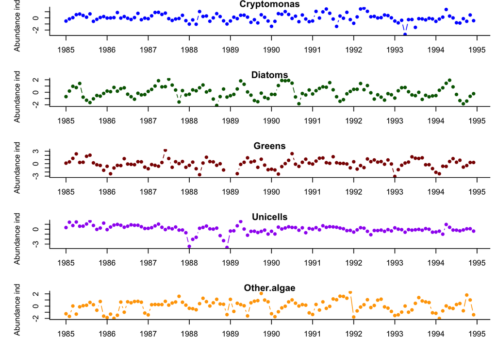

# Methods

## Phytoplankton abundance

We examined models that consider phytoplankton abundance being driven by three underlying state options: one, two, or three states. We also test three observation error matrices, diagonal and equal, diagonal and unequal, and equal variance and covariance. Our aim is to consider all combinations of three environmental covariates and how they relate to phytoplankton abundance.

[output not shown]

[output cut: 71 more lines]

[output not shown]

```
##    ModelID NumStates              R_Model      Covariates     AICc
## 1   model6         1 diagonal and unequal     Temp and pH 1363.484
## 2   model7         1 diagonal and unequal Temp,TP, and pH 1369.766
## 3  model13         1          equalvarcov     Temp and pH 1380.009
## 4  model14         1          equalvarcov Temp,TP, and pH 1383.319
## 5  model20         1   diagonal and equal     Temp and pH 1386.353
## 6  model21         1   diagonal and equal Temp,TP, and pH 1392.531
## 7   model4         1 diagonal and unequal     Temp and TP 1407.195
## 8   model1         1 diagonal and unequal            Temp 1414.070
## 9   model5         1 diagonal and unequal       TP and pH 1419.575
## 10 model11         1          equalvarcov     Temp and TP 1422.335
```

```
##
## m: 1 state process(es) named X1
## n: 5 observation time series named Cryptomonas Diatoms Greens Unicells Other.algae
##
##                           term     estimate
## 1                          Z.z  0.228921514
## 2  R.(Cryptomonas,Cryptomonas)  0.286298723
## 3          R.(Diatoms,Diatoms)  0.359174667
## 4            R.(Greens,Greens)  0.795606135
## 5        R.(Unicells,Unicells)  0.459922393
## 6  R.(Other.algae,Other.algae)  0.592193147
## 7                          U.U -0.003203026
## 8         D.(Cryptomonas,Temp) -0.061784997
## 9             D.(Diatoms,Temp) -0.477653425
## 10             D.(Greens,Temp)  0.509988337
## 11           D.(Unicells,Temp)  0.026200248
## 12        D.(Other.algae,Temp)  0.575190541
## 13          D.(Cryptomonas,pH)  0.164410907
## 14              D.(Diatoms,pH)  0.523675641
## 15               D.(Greens,pH)  0.102655170
## 16             D.(Unicells,pH)  0.099820498
## 17          D.(Other.algae,pH) -0.115068612
```

```
##                    X1
## Cryptomonas 0.2289215
## Diatoms     0.2289215
## Greens      0.2289215
## Unicells    0.2289215
## Other.algae 0.2289215
```

```
##                    [,1]       [,2]
## Cryptomonas -0.06178500  0.1644109
## Diatoms     -0.47765342  0.5236756
## Greens       0.50998834  0.1026552
## Unicells     0.02620025  0.0998205
## Other.algae  0.57519054 -0.1150686
```

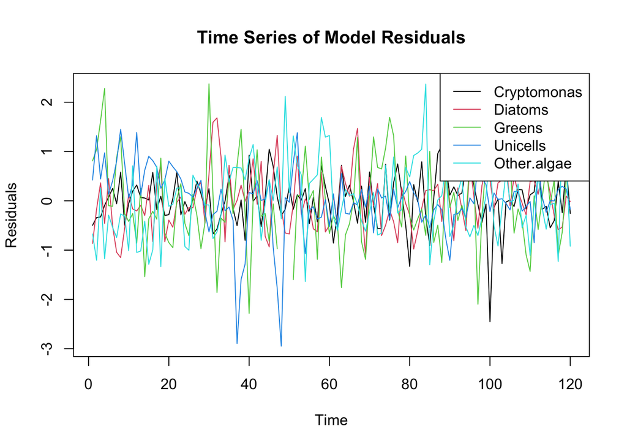

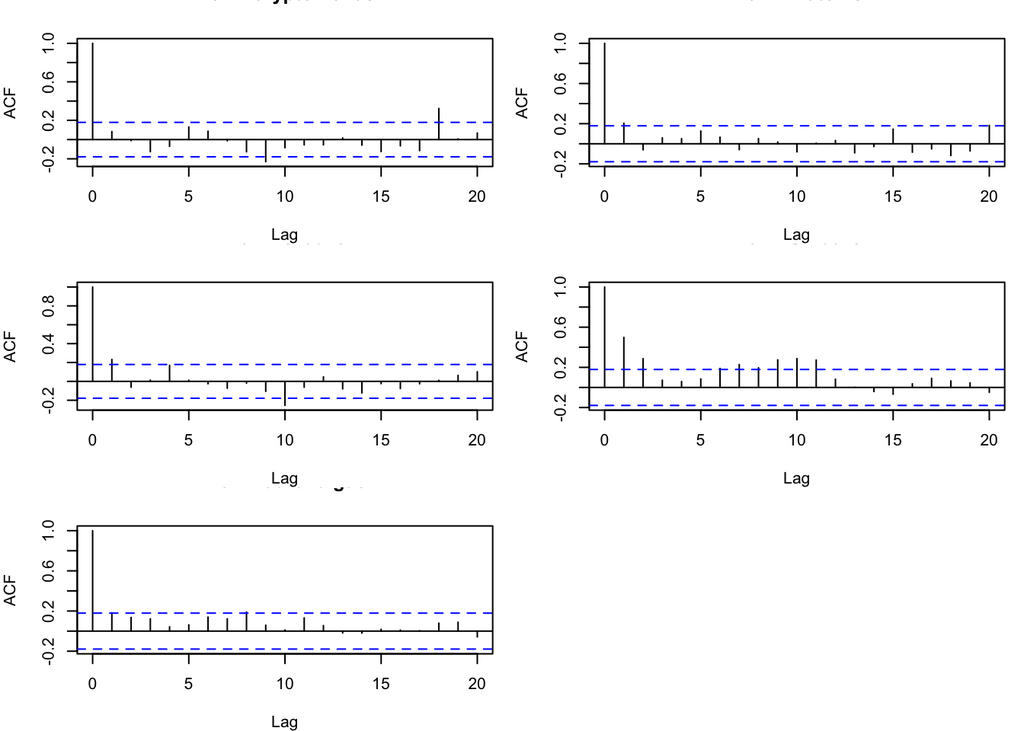

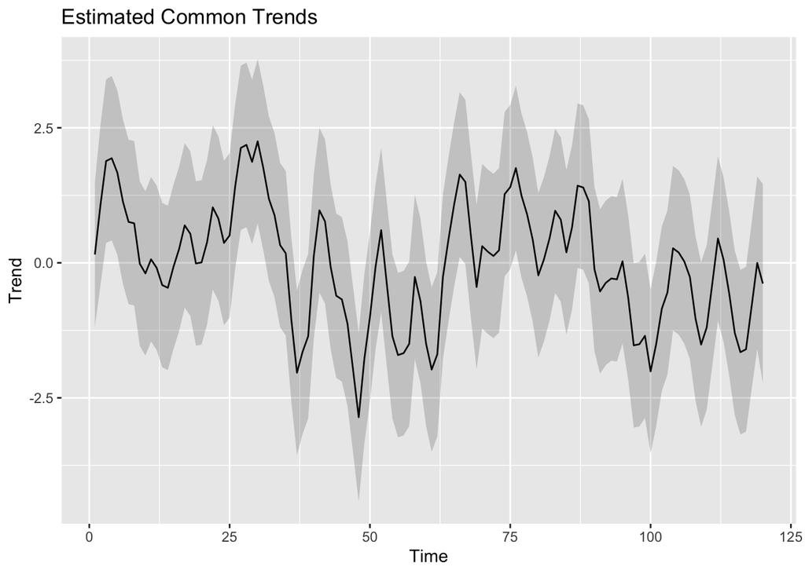

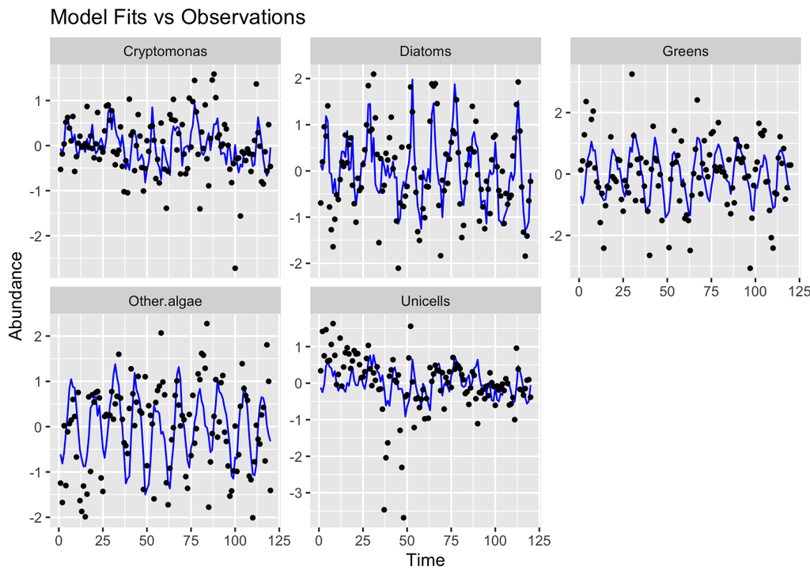

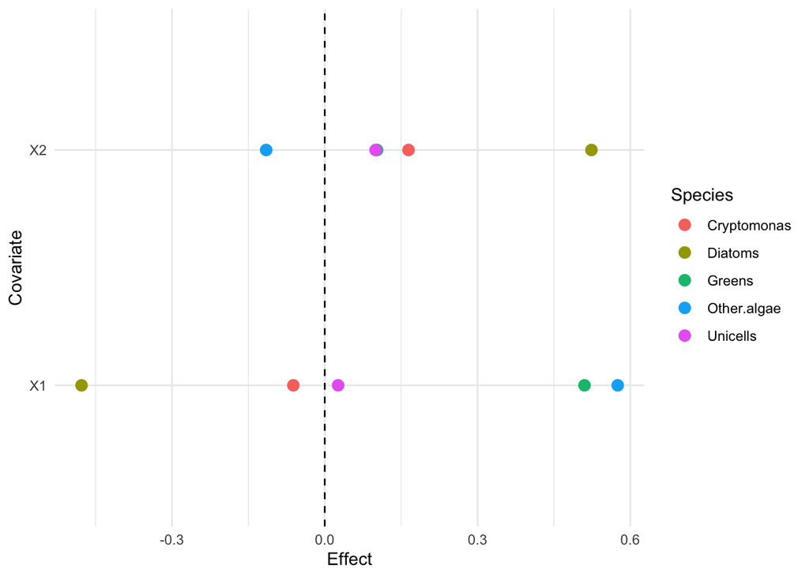

## Zooplankton abundance

This analysis includes model comparison to determine the optimal number of hidden states that drive zooplankton abundance.

Loading and wrangling data:

```r
library(MARSS)
library(ggplot2)
library(dplyr)
library(ggpubr)

data(lakeWAplankton, package = "MARSS")

data = lakeWAplanktonTrans

zooplankton = c("Conochilus", "Cyclops", "Daphnia", "Diaptomus", "Epischura",
                "Leptodora", "Non.daphnid.cladocerans", "Non.colonial.rotifers") # I'm excluding 'Neomysis' since they dont have lots of data

env_covars = c("Temp", "TP", "pH")

time_vars = c("Year", "Month")

combined = unique(c(zooplankton, env_covars, time_vars))

# filter data
data = lakeWAplanktonTrans[, colnames(lakeWAplanktonTrans) %in% combined, drop = FALSE]

# select zooplankton only and de-mean data
zoop_data = data[, colnames(data) %in% zooplankton, drop = FALSE]
y_mean    = apply(zoop_data, 2, mean, na.rm = TRUE)
zoop_data = zoop_data - y_mean

# select last 10 years only
zoop_data = zoop_data[120:dim(zoop_data)[2],]

# transpose so time is columns
zoop_data = t(zoop_data)
N_ts      = nrow(zoop_data)
TT        = ncol(zoop_data)
```

Plotting:

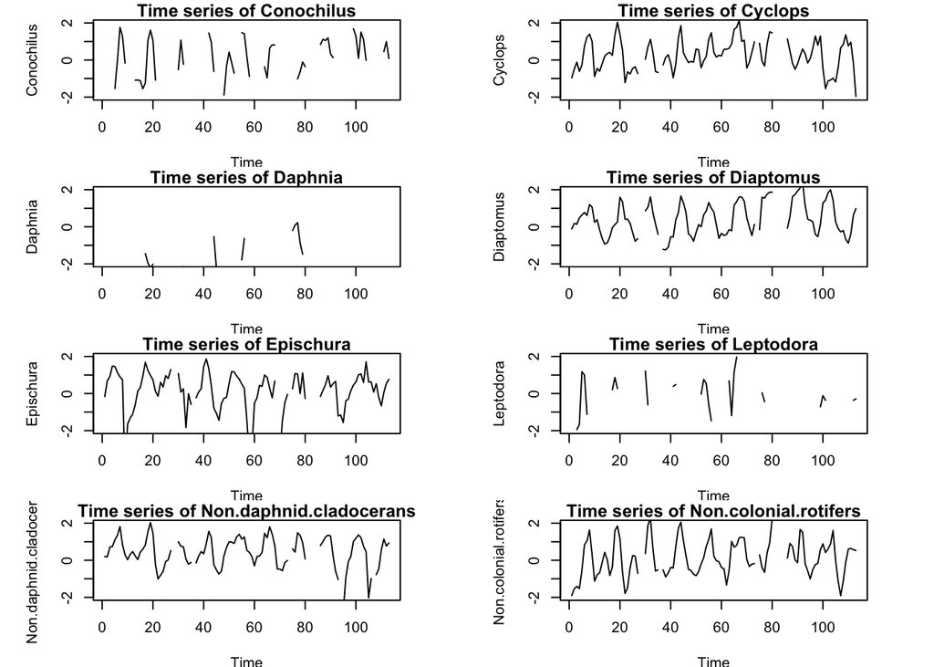

```r
cnt = 1
par(mfrow = c(4, 2), mai = c(0.5, 0.7, 0.15, 0.5), omi = c(0, 0, 0, 0))

for (i in zooplankton) {
  plot(zoop_data[cnt, ], type = "l", xlab = "Time", ylab = i,
       main = paste("Time series of", i), ylim = c(-2, 2))
  cnt = cnt + 1
}
```

#### Model 1: 1 Hidden State

##### The observation model

$$\begin{bmatrix}
Y_{1t} \\
Y_{2t} \\
Y_{3t} \\
Y_{4t} \\
Y_{5t} \\
Y_{6t} \\
Y_{7t} \\
Y_{8t}
\end{bmatrix}
=
\begin{bmatrix}
z_{11} \\
z_{21} \\
z_{31} \\
z_{41} \\
z_{51} \\
z_{61} \\
z_{71} \\
z_{81}
\end{bmatrix}
X_t
+
\begin{bmatrix}
0 \\
0 \\
0 \\
0 \\
0 \\
0 \\
0 \\
0
\end{bmatrix}
+
\begin{bmatrix}
0 \\
0 \\
0 \\
0 \\
0 \\
0 \\
0 \\
0
\end{bmatrix}
+
\varepsilon_t$$
Where: - $\varepsilon_t \sim N(0, R)$ - The variance-covariance matrix $R$ is:
$$R =
\begin{bmatrix}
\sigma_1^2 & 0 & 0 & 0 & 0 & 0 & 0 & 0 \\
0 & \sigma_2^2 & 0 & 0 & 0 & 0 & 0 & 0 \\
0 & 0 & \sigma_3^2 & 0 & 0 & 0 & 0 & 0 \\
0 & 0 & 0 & \sigma_4^2 & 0 & 0 & 0 & 0 \\
0 & 0 & 0 & 0 & \sigma_5^2 & 0 & 0 & 0 \\
0 & 0 & 0 & 0 & 0 & \sigma_6^2 & 0 & 0 \\
0 & 0 & 0 & 0 & 0 & 0 & \sigma_7^2 & 0 \\
0 & 0 & 0 & 0 & 0 & 0 & 0 & \sigma_8^2
\end{bmatrix}$$

$$X_t =
\begin{bmatrix}
1
\end{bmatrix}
X_{t-1} +
\begin{bmatrix}
0
\end{bmatrix}
+
\begin{bmatrix}
0
\end{bmatrix}
+
\eta_t$$

Where: - $\eta_t \sim N(0, Q)$ - The variance-covariance matrix $Q$ is:
$$Q =
\begin{bmatrix}
1
\end{bmatrix}$$

```r
###### Model 1: 1 Hidden State ######

## 1. Observation model
Z_vals_1 = list(  "z11"  ,
                  "z21",
                  "z31",
                  "z41",
                  "z51",
                  "z61",
                  "z71",
                  "z81" )

ZZ_1 = matrix(Z_vals_1, nrow = N_ts, ncol = 1, byrow = TRUE)
aa_1 = "zero"
DD_1 = "zero"                 # no covariates
dd_1 = "zero"
RR_1 = "diagonal and unequal" # observation error variance-covariance matrix

## 2. Process model
mm_1 = 1           # number of hidden states
BB_1 = "identity"  # diag(mm)
uu_1 = "zero"      # process bias (i.e. growth rate)
CC_1 = "zero"      # no covariates
cc_1 = "zero"
QQ_1 = "identity"  # process error variance-covariance matrix

mod_list_1 = list(Z = ZZ_1, A = aa_1, D = DD_1, d = dd_1, R = RR_1,
                  B = BB_1, U = uu_1, C = CC_1, c = cc_1, Q = QQ_1)

init_list_1 = list(x0 = 0)

con_list_1   = list(maxit = 1000, allow.degen = TRUE)
dfa_1_hidden = MARSS(y = zoop_data, model = mod_list_1, inits = init_list_1, control = con_list_1)
```

```
## Warning! Abstol convergence only. Maxit (=1000) reached before log-log convergence.
##
## MARSS fit is
## Estimation method: kem
## Convergence test: conv.test.slope.tol = 0.5, abstol = 0.001
## WARNING: Abstol convergence only no log-log convergence.
##  maxit (=1000) reached before log-log convergence.
##  The likelihood and params might not be at the ML values.
##  Try setting control$maxit higher.
## Log-likelihood: -803.117
## AIC: 1640.234   AICc: 1641.218
##
##                                                     Estimate
## Z.z11                                                0.17876
## Z.z21                                                0.11654
## Z.z31                                               -0.49427
## Z.z41                                                0.54916
## Z.z51                                                0.08283
## Z.z61                                                0.04539
## Z.z71                                                0.20260
## Z.z81                                                0.28688
## R.(Conochilus,Conochilus)                            0.95230
## R.(Cyclops,Cyclops)                                  0.69524
## R.(Daphnia,Daphnia)                                  1.27627
## R.(Diaptomus,Diaptomus)                              0.00365
## R.(Epischura,Epischura)                              1.19087
## R.(Leptodora,Leptodora)                              0.93874
## R.(Non.daphnid.cladocerans,Non.daphnid.cladocerans)  0.74858
## R.(Non.colonial.rotifers,Non.colonial.rotifers)      0.67695
## x0.x0                                               -0.21013
## Initial states (x0) defined at t=0
##
## Standard errors have not been calculated.
## Use MARSSparamCIs to compute CIs and bias estimates.
##
## Convergence warnings
##  Warning: the  R.(Diaptomus,Diaptomus)  parameter value has not converged.
##  Type MARSSinfo("convergence") for more info on this warning.
```

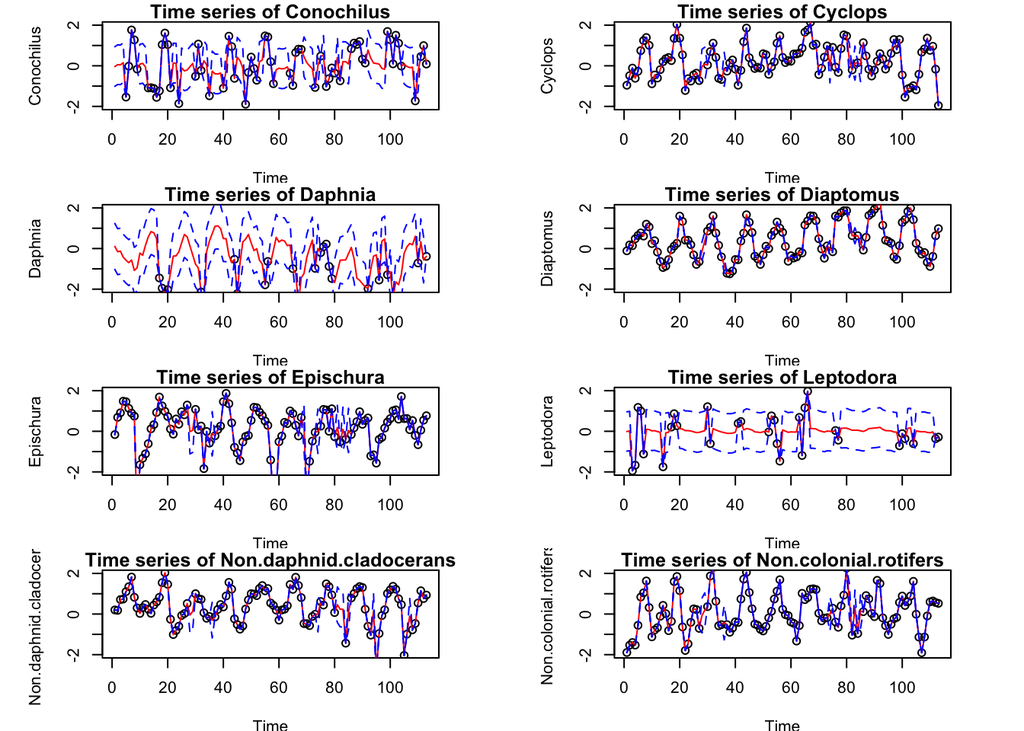

```r
## Plot fits against data
model_1_fits    = dfa_1_hidden$ytT
model_1_fits_se = dfa_1_hidden$ytT.se

par(mfrow = c(4, 2), mai = c(0.5, 0.7, 0.15, 0.5), omi = c(0, 0, 0, 0))
cnt = 1
for (i in zooplankton) {
  plot(zoop_data[cnt, ], type = "p", xlab = "Time", ylab = i,
       main = paste("Time series of", i), ylim = c(-2, 2))
  lines(model_1_fits[cnt, ], col = "red")
  lines(model_1_fits[cnt, ] + model_1_fits_se[cnt, ], col = "blue", lty = 2)
  lines(model_1_fits[cnt, ] - model_1_fits_se[cnt, ], col = "blue", lty = 2)
  cnt = cnt + 1
}
```

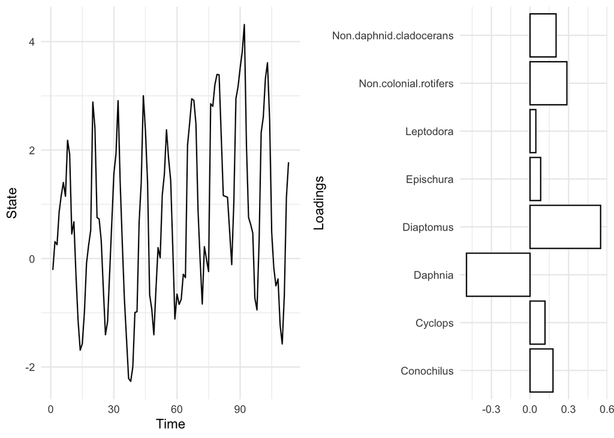

```r
## Plot states and loadings
Z_est_1 = coef(dfa_1_hidden, type = "matrix")$Z
H_inv_1 = varimax(Z_est_1)

states_1 = as.vector(dfa_1_hidden$states)
states_1 = data.frame(1:TT, states_1); names(states_1) = c("Time", "State")

states_plot_1 = states_1 %>%
  ggplot(aes(x = Time, y = State)) +
  geom_line() +
  theme_minimal()

loadings_1 = as.vector(H_inv_1[,1])
loadings_1 = data.frame(loadings_1, zooplankton)

loadings_plot_1 = loadings_1 %>%
  ggplot(aes(x = zooplankton, y = loadings_1)) +
  geom_bar(stat = "identity", fill = "white", color = "black") +
  theme_minimal() +
  coord_flip() +
  ylab("") +
  xlab("Loadings")

ggarrange(states_plot_1, loadings_plot_1)
```

#### Model 2: 2 Hidden States

##### The process model

$$\begin{bmatrix}
X_{1t} \\
X_{2t}
\end{bmatrix}
=
\begin{bmatrix}
1 & 0 \\
0 & 1
\end{bmatrix}
\begin{bmatrix}
X_{1, t-1} \\
X_{2, t-1}
\end{bmatrix}
+
\begin{bmatrix}
0 \\
0
\end{bmatrix}
+
\begin{bmatrix}
0 \\
0
\end{bmatrix}
+
\eta_t$$

Where: - $\eta_t \sim N(0, Q)$ - The variance-covariance matrix $Q$ is:
$$Q =
\begin{bmatrix}
1 & 0 \\
0 & 1
\end{bmatrix}$$

```r
###### Model 2: 2 Hidden States ######

## 1. Observation model
Z_vals_2 = list(  0  , 0  ,
                "z21", 0  ,
                "z31","z32",
                "z41","z42",
                "z51","z52",
                "z61","z62",
                "z71","z72",
                "z81","z82")
ZZ_2 = matrix(Z_vals_2, nrow = N_ts, ncol = 2, byrow = TRUE)
aa_2 = "zero"
DD_2 = "zero"                 # no covariates
dd_2 = "zero"
RR_2 = "diagonal and unequal" # observation error variance-covariance matrix

## 2. Process model
mm_2 = 2           # number of hidden states
BB_2 = "identity"  # diag(mm)
uu_2 = "zero"      # process bias (i.e. growth rate)
CC_2 = "zero"      # no covariates
cc_2 = "zero"
QQ_2 = "identity"  # process error variance-covariance matrix

mod_list_2 = list(Z = ZZ_2, A = aa_2, D = DD_2, d = dd_2, R = RR_2,
                  B = BB_2, U = uu_2, C = CC_2, c = cc_2, Q = QQ_2)

init_list_2 = list(x0 = matrix(rep(0, mm_2), mm_2, 1))

con_list_2 = list(maxit = 1000, allow.degen = TRUE)
dfa_2_hidden = MARSS(y = zoop_data, model = mod_list_2, inits = init_list_2, control = con_list_2)
```

```
## Warning! Abstol convergence only. Maxit (=1000) reached before log-log convergence.
##
## MARSS fit is
## Estimation method: kem
## Convergence test: conv.test.slope.tol = 0.5, abstol = 0.001
## WARNING: Abstol convergence only no log-log convergence.
##  maxit (=1000) reached before log-log convergence.
##  The likelihood and params might not be at the ML values.
##  Try setting control$maxit higher.
## Log-likelihood: -767.9991
## AIC: 1581.998   AICc: 1583.79
##
##                                                      Estimate
## Z.z21                                                0.683088
## Z.z31                                               -0.383514
## Z.z41                                                0.076182
## Z.z51                                               -0.047379
## Z.z61                                                0.090716
## Z.z71                                                0.215526
## Z.z81                                                0.334331
## Z.z32                                               -0.365318
## Z.z42                                                0.546179
## Z.z52                                                0.091521
## Z.z62                                                0.037061
## Z.z72                                                0.166646
## Z.z82                                                0.233195
## R.(Conochilus,Conochilus)                            1.082460
## R.(Cyclops,Cyclops)                                  0.001671
## R.(Daphnia,Daphnia)                                  0.995033
## R.(Diaptomus,Diaptomus)                              0.000893
## R.(Epischura,Epischura)                              1.185638
## R.(Leptodora,Leptodora)                              0.923139
## R.(Non.daphnid.cladocerans,Non.daphnid.cladocerans)  0.694421
## R.(Non.colonial.rotifers,Non.colonial.rotifers)      0.543357
## x0.X1                                               -1.402002
## x0.X2                                               -0.011606
## Initial states (x0) defined at t=0
##
## Standard errors have not been calculated.
## Use MARSSparamCIs to compute CIs and bias estimates.
##
## Convergence warnings
##  Warning: the  R.(Cyclops,Cyclops)  parameter value has not converged.
##  Warning: the  R.(Diaptomus,Diaptomus)  parameter value has not converged.
##  Type MARSSinfo("convergence") for more info on this warning.
```

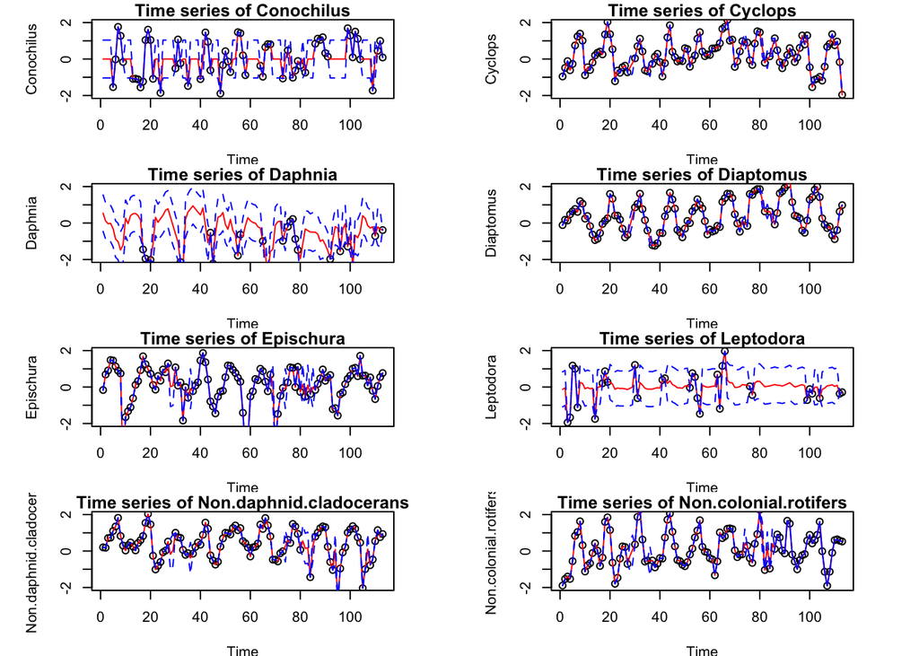

```r
## Plot fits against data
model_2_fits    = dfa_2_hidden$ytT
model_2_fits_se = dfa_2_hidden$ytT.se

par(mfrow = c(4, 2), mai = c(0.5, 0.7, 0.15, 0.5), omi = c(0, 0, 0, 0))
cnt = 1
for (i in zooplankton) {
  plot(zoop_data[cnt, ], type = "p", xlab = "Time", ylab = i,
       main = paste("Time series of", i), ylim = c(-2, 2))
  lines(model_2_fits[cnt, ], col = "red")
  lines(model_2_fits[cnt, ] + model_2_fits_se[cnt, ], col = "blue", lty = 2)
  lines(model_2_fits[cnt, ] - model_2_fits_se[cnt, ], col = "blue", lty = 2)
  cnt = cnt + 1
}
```

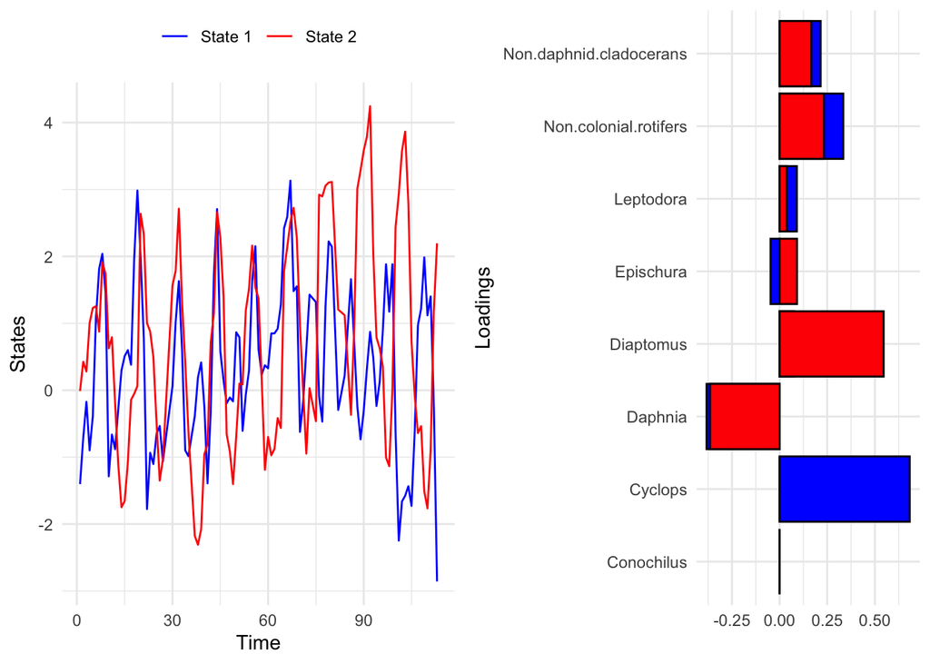

```r
## Plot states and loadings
Z_est_2 = coef(dfa_2_hidden, type = "matrix")$Z
#H_inv_2 = varimax(Z_est_2)$rotmat

states_2 = as.data.frame(t(dfa_2_hidden$states))
states_2 = data.frame(1:TT, states_2); names(states_2) = c("Time", "State 1", "State 2")

states_plot_2 = states_2 %>%
  ggplot(aes(x = Time)) +
  geom_line(aes(y = `State 1`, color = "State 1")) +
  geom_line(aes(y = `State 2`, color = "State 2")) +
  theme_minimal() +
  ylab("States") +
  scale_color_manual(values = c("blue", "red")) +
  theme(legend.title = element_blank(),
        legend.position = "top")

loadings_2 = as.data.frame(Z_est_2)
loadings_2 = data.frame(loadings_2, zooplankton)
loadings_plot_2 = loadings_2 %>%
  ggplot(aes(x = zooplankton)) +
  geom_bar(aes(y = X1), stat = "identity", fill = "blue", color = "black") +
  geom_bar(aes(y = X2), stat = "identity", fill = "red", color = "black") +
  theme_minimal() +
  coord_flip() +
  ylab("") +
  xlab("Loadings")

ggarrange(states_plot_2, loadings_plot_2)
```

#### Model 3: 3 Hidden States

##### The observation model

$$\begin{bmatrix}
Y_{1t} \\
Y_{2t} \\
Y_{3t} \\
Y_{4t} \\
Y_{5t} \\
Y_{6t} \\
Y_{7t} \\
Y_{8t}
\end{bmatrix}
=
\begin{bmatrix}
z_{11} & 0 & 0 \\
z_{21} & z_{22} & 0 \\
z_{31} & z_{32} & z_{33} \\
z_{41} & z_{42} & z_{43} \\
z_{51} & z_{52} & z_{53} \\
z_{61} & z_{62} & z_{63} \\
z_{71} & z_{72} & z_{73} \\
z_{81} & z_{82} & z_{83}
\end{bmatrix}
\begin{bmatrix}
X_{1t} \\
X_{2t} \\
X_{3t}
\end{bmatrix}
+
\begin{bmatrix}
0 \\
0 \\
0 \\
0 \\
0 \\
0 \\
0 \\
0
\end{bmatrix}
+
\begin{bmatrix}
0 \\
0 \\
0 \\
0 \\
0 \\
0 \\
0 \\
0
\end{bmatrix}
+
\varepsilon_t$$

Where: - $\varepsilon_t \sim N(0, R)$ - The variance-covariance matrix $R$ is:
$$R =
\begin{bmatrix}
\sigma_1^2 & 0 & \cdots & 0 \\
0 & \sigma_2^2 & \cdots & 0 \\
\vdots & \vdots & \ddots & \vdots \\
0 & 0 & \cdots & \sigma_8^2
\end{bmatrix}$$
##### The process model
$$\begin{bmatrix}
X_{1t} \\
X_{2t} \\
X_{3t}
\end{bmatrix}
=
\begin{bmatrix}
1 & 0 & 0 \\
0 & 1 & 0 \\
0 & 0 & 1
\end{bmatrix}
\begin{bmatrix}
X_{1, t-1} \\
X_{2, t-1} \\
X_{3, t-1}
\end{bmatrix}
+
\begin{bmatrix}
0 \\
0 \\
0
\end{bmatrix}
+
\begin{bmatrix}
0 \\
0 \\
0
\end{bmatrix}
+
\eta_t$$

Where: - $\eta_t \sim N(0, Q)$ - The variance-covariance matrix $Q$ is:
$$Q =
\begin{bmatrix}
1 & 0 & 0 \\
0 & 1 & 0 \\
0 & 0 & 1
\end{bmatrix}$$

```r
###### Model 3: 3 Hidden States ######

## 1. Observation model
Z_vals_3 = list("z11",  0  ,  0  ,
                "z21","z22",  0  ,
                "z31","z32","z33",
                "z41","z42","z43",
                "z51","z52","z53",
                "z61","z62","z63",
                "z71","z72","z73",
                "z81","z82","z83")
ZZ_3 = matrix(Z_vals_3, nrow = N_ts, ncol = 3, byrow = TRUE)
aa_3 = "zero"
DD_3 = "zero"                 # no covariates
dd_3 = "zero"
RR_3 = "diagonal and unequal" # observation error variance-covariance matrix

## 2. Process model
mm_3 = 3           # number of hidden states
BB_3 = "identity"  # diag(mm)
uu_3 = "zero"      # process bias (i.e. growth rate)
CC_3 = "zero"      # no covariates
cc_3 = "zero"
QQ_3 = "identity"  # process error variance-covariance matrix

mod_list_3 = list(Z = ZZ_3, A = aa_3, D = DD_3, d = dd_3, R = RR_3,
                  B = BB_3, U = uu_3, C = CC_3, c = cc_3, Q = QQ_3)

init_list_3 = list(x0 = matrix(rep(0, mm_3), mm_3, 1))

con_list_3 = list(maxit = 1000, allow.degen = TRUE)
dfa_3_hidden = MARSS(y = zoop_data, model = mod_list_3, inits = init_list_3, control = con_list_3)
```

```
## Success! abstol and log-log tests passed at 363 iterations.
## Alert: conv.test.slope.tol is 0.5.
## Test with smaller values (<0.1) to ensure convergence.
##
## MARSS fit is
## Estimation method: kem
## Convergence test: conv.test.slope.tol = 0.5, abstol = 0.001
## Estimation converged in 363 iterations.
## Log-likelihood: -758.4804
## AIC: 1580.961   AICc: 1584.44
##
##                                                     Estimate
## Z.z11                                                0.90845
## Z.z21                                                0.31519
## Z.z31                                               -0.25953
## Z.z41                                                0.19768
## Z.z51                                                0.17169
## Z.z61                                                0.09890
## Z.z71                                                0.43941
## Z.z81                                                0.50173
## Z.z22                                                0.59332
## Z.z32                                               -0.29086
## Z.z42                                                0.06993
## Z.z52                                               -0.19846
## Z.z62                                                0.06740
## Z.z72                                               -0.06628
## Z.z82                                                0.23244
## Z.z33                                               -0.28645
## Z.z43                                                0.14131
## Z.z53                                                0.24761
## Z.z63                                               -0.00659
## Z.z73                                                0.42172
## Z.z83                                                0.05827
## R.(Conochilus,Conochilus)                            0.09804
## R.(Cyclops,Cyclops)                                  0.01132
## R.(Daphnia,Daphnia)                                  1.19542
## R.(Diaptomus,Diaptomus)                              0.79434
## R.(Epischura,Epischura)                              0.93737
## R.(Leptodora,Leptodora)                              0.91852
## R.(Non.daphnid.cladocerans,Non.daphnid.cladocerans)  0.01253
## R.(Non.colonial.rotifers,Non.colonial.rotifers)      0.43868
## x0.X1                                               -3.96861
## x0.X2                                                0.51040
## x0.X3                                                4.66717
## Initial states (x0) defined at t=0
##
## Standard errors have not been calculated.
## Use MARSSparamCIs to compute CIs and bias estimates.
```

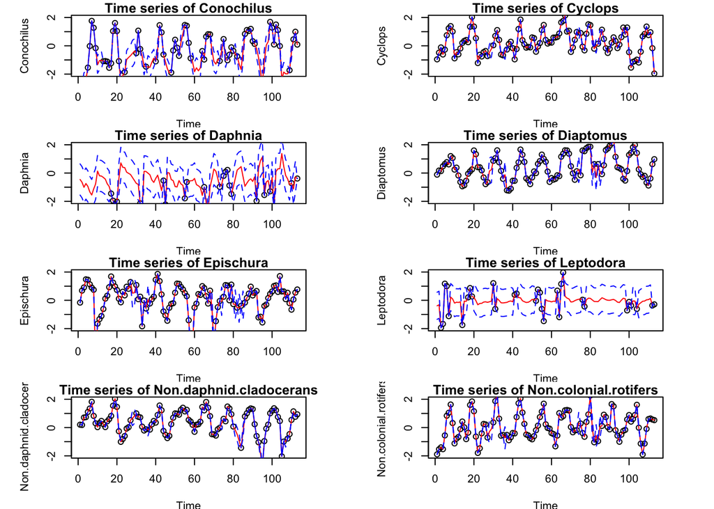

```r
## Plot fits against data
model_3_fits    = dfa_3_hidden$ytT
model_3_fits_se = dfa_3_hidden$ytT.se
par(mfrow = c(4, 2), mai = c(0.5, 0.7, 0.15, 0.5), omi = c(0, 0, 0, 0))
cnt = 1
for (i in zooplankton) {
  plot(zoop_data[cnt, ], type = "p", xlab = "Time", ylab = i,
       main = paste("Time series of", i), ylim = c(-2, 2))
  lines(model_3_fits[cnt, ], col = "red")
  lines(model_3_fits[cnt, ] + model_3_fits_se[cnt, ], col = "blue", lty = 2)
  lines(model_3_fits[cnt, ] - model_3_fits_se[cnt, ], col = "blue", lty = 2)
  cnt = cnt + 1
}
```

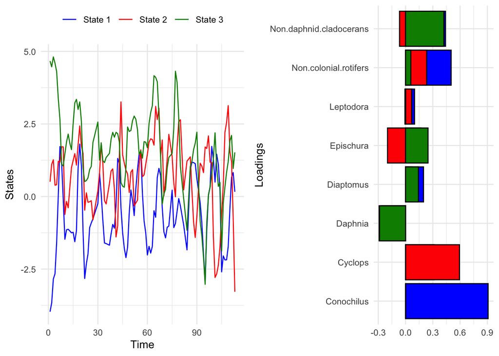

```r
## Plot states and loadings
Z_est_3 = coef(dfa_3_hidden, type = "matrix")$Z
H_inv_3 = varimax(Z_est_3)$rotmat

states_3 = as.data.frame(t(dfa_3_hidden$states))
states_3 = data.frame(1:TT, states_3); names(states_3) = c("Time", "State 1", "State 2", "State 3")
states_plot_3 = states_3 %>%
  ggplot(aes(x = Time)) +
  geom_line(aes(y = `State 1`, color = "State 1")) +
  geom_line(aes(y = `State 2`, color = "State 2")) +
  geom_line(aes(y = `State 3`, color = "State 3")) +
  theme_minimal() +
  ylab("States") +
  scale_color_manual(values = c("blue", "red", "green4")) +
  theme(legend.title = element_blank(),
        legend.position = "top")

loadings_3 = as.data.frame(Z_est_3)
loadings_3 = data.frame(loadings_3, zooplankton)
loadings_plot_3 = loadings_3 %>%
  ggplot(aes(x = zooplankton)) +
  geom_bar(aes(y = X1), stat = "identity", fill = "blue", color = "black") +
  geom_bar(aes(y = X2), stat = "identity", fill = "red", color = "black") +
  geom_bar(aes(y = X3), stat = "identity", fill = "green4", color = "black") +
  theme_minimal() +
  coord_flip() +
  ylab("") +
  xlab("Loadings")

ggarrange(states_plot_3, loadings_plot_3)
```

##### Comparing models

```r
### Make a model comparison table
model_comparison = data.frame(
  Model = c("Model 1", "Model 2", "Model 3"),
  AIC = c(dfa_1_hidden$AIC, dfa_2_hidden$AIC, dfa_3_hidden$AIC)
)
model_comparison = model_comparison %>%
  mutate(Delta_AIC = AIC - min(AIC),
         Weight = exp(-0.5 * Delta_AIC) / sum(exp(-0.5 * Delta_AIC)))

model_comparison
```

```
##     Model      AIC Delta_AIC       Weight
## 1 Model 1 1640.234 59.273129 8.436486e-14
## 2 Model 2 1581.998  1.037385 3.731580e-01
## 3 Model 3 1580.961  0.000000 6.268420e-01
```

## Grazer abundance, phytoplankton covariates

This final section of our analysis focuses on modeling grazing zooplankton, treating phytoplankton abundance as a covariate as grazers feed on phytoplankton. The dataset contains time series abundance data on six species of grazing zooplankton: conochilus, cyclops, daphnia, diaptomus, non-daphnid cladocerans, and non- colonial rotifers. The first stage of this process involves modeling phytoplankton using a traditional MARSS model and recording model estimates of the underlying state of phytoplankton in Lake Washington. The next stage utilizes a dynamica factor analysis framework to consider zooplankton grazer abundance.

#### Modeling phytoplankton

Modeling phytoplankton abundance with traditional MARSS models is necessary for two reasons. One, the dynamic factor analysis of zooplankton grazers will include phytoplankton abundance as covariates. Covariates included in DFA models must have no missing data, and the observed phytoplankton data contains some gaps in the time series. Using MARSS models, the underlying state of phytoplankton abundance can be estimated with no missing data points. These estimates will then be passed into the DFA model. The second reason is that treating time series of five distinct phytoplankton species as representative samples of one underlying state of phytoplankton abundance is likely all that is required to observe the impact of phytoplankton abundance on the abundance of grazing zooplankton. Unless grazers are very selective in their diets, the overall level of phytoplankton in a given time period will likely be more important than the abundances of five individual phtoplankton groupings.

This analysis begins by considering two models with different covariate structures: one which takes into account Lake Washington’s temperature, pH level, and total phosphorous measures, and another which includes a matrix of ones and zeroes corresponding to each month in order captrue seasonal trends. Each model treats each category of phytoplankton as its own underlying state.

```
##      Model     AICc
## 1 seasonal 1372.241
## 2  climate 1421.726
```

Per AICc, the model including seasonal covariates (as opposed to lake temperature and chemical compsotion) is a better fit for phytoplankton data. Abundances are described in the figure below.

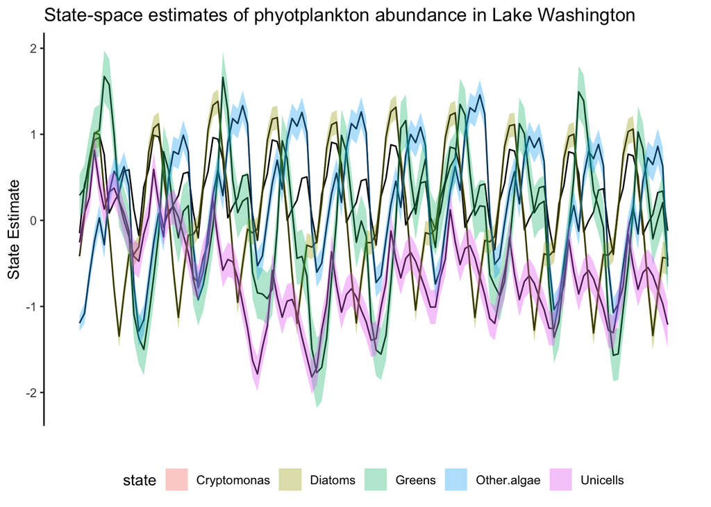

Next we consider models which treat all five time series of phytoplankton groups as representative samples from one larger underlying state of phytoplankton abundance in Lake Washington. Once again, the two covariate structures described above will be evaluated for best fit.

```
##      Model     AICc
## 1 seasonal 1595.392
## 2  climate 1617.200
```

As before, AICc finds that the model including seasonal covariates is a better fit for phytoplankton data. This overall abundance of phytoplankton is described in the figure below.

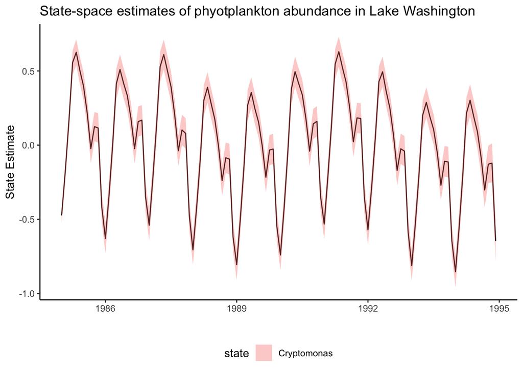

This model of phytoplankton abundance as one underlying state will be used going forward in the dynamic factor analysis of zooplankton grazers.

#### Modeling grazing zooplankton

With phytoplankton abundance estimates in hand, we now move on to the evaluation of zooplankton grazers using dynamic factor analysis. We begin by considering which number of underlying will best fit the model. We evealutate models with 1 to 5 underlying factors (as there are six time series of zooplankton grazers it is appropriate at most to consider one fewer factor). These initial models will include covariates describing temperature, pH, and phytoplankton abundance. One the best fit is determined in terms of underlying factors, these covariates will be additionally evaluated to determine whether they are all necessaty.

```
##   Model     AICc
## 1 zoo_1 1519.438
## 2 zoo_2 1455.378
## 3 zoo_3 1397.704
## 4 zoo_4 1361.781
## 5 zoo_5 1366.228
```

AICc determines that the model with four underlying factors is the best fit per the data. WE now move on to evaluating which set of covariates are best suited to improve model fit. All possible combinations of water temperature, pH levels, and phytoplankton abundance will be considered. Also, a seasonal covariate will be introduced and considered both on it’s own and as part of other covariate combinations, yielding a total of 15 covariate structures to be considered.

```
##     Model     AICc
## 1   cov_1 1341.352
## 2   cov_2 1436.280
## 3   cov_3 1457.614
## 4   cov_4 1451.671
## 5   cov_5 1397.265
## 6   cov_6 1406.253
## 7   cov_7 1400.197
## 8   cov_8 1354.193
## 9   cov_9 1411.371
## 10 cov_10 1370.936
## 11 cov_11 1415.082
## 12 cov_12 1382.479
## 13 cov_13 1375.080
## 14 cov_14 1336.920
## 15 cov_15 1387.180
```

```
##                         Phytoplankton         pH
## Conochilus                  1.6638674 0.25854318
## Cyclops                     1.3375586 0.47084278
## Daphnia                     1.0316220 0.10671744
## Diaptomus                   0.1591784 0.03867884
## Non.daphnid.cladocerans     1.0875686 0.22313026
## Non.colonial.rotifers       2.3166329 0.54293057
```

AICc finds that a model which allows for four underlying factors and includes phytoplankton abundance and pH levels as well as a seasonal component best describes the zooplankton grazer abundance data. The effects of phytoplankton abundance and pH levels on each species of grazer are reported in the table above.

# Results

## Grazer abundance, phytoplankton covariates

With a best fit model in hand, the next step is to determine a rotation matrix H that maximizes the difference between loadings in Z, to better understand what grazer zooplankton species abundances are being driven by which underlying factors.

```
##             [,1]       [,2]         [,3]      [,4]
## [1,]  0.95829751  0.2023851  0.042066713 0.1973235
## [2,] -0.26316742  0.8947791 -0.001745441 0.3607080
## [3,] -0.10530862 -0.3070454  0.649097868 0.6879718
## [4,] -0.03631655 -0.2532465 -0.759538875 0.5980368
```

```
##                                  X1         X2          X3         X4
## Conochilus               0.45194221  0.0000000  0.00000000  0.0000000
## Cyclops                 -0.04560840  0.5473941  0.00000000  0.0000000
## Daphnia                  0.08725003  0.3986525  0.13777171  0.0000000
## Diaptomus                0.27631365 -0.1310085 -0.02472144  0.0184231
## Non.daphnid.cladocerans  0.23848590  0.3093313  0.22171647  0.2179589
## Non.colonial.rotifers    0.25781133  0.3702879 -0.08723267 -0.0313959
```

```
##                               [,1]        [,2]         [,3]        [,4]
## Conochilus               0.4330951  0.09146637  0.019011723 0.089178805
## Cyclops                 -0.1877627  0.48056637 -0.002874039 0.188449838
## Daphnia                 -0.0358094  0.33206183  0.092401818 0.255796659
## Diaptomus                0.3012022 -0.05837688 -0.018187419 0.001277391
## Non.daphnid.cladocerans  0.1158704  0.20177481 -0.012140204 0.441519278
## Non.colonial.rotifers    0.1599388  0.41823830 -0.022577174 0.105648504
```

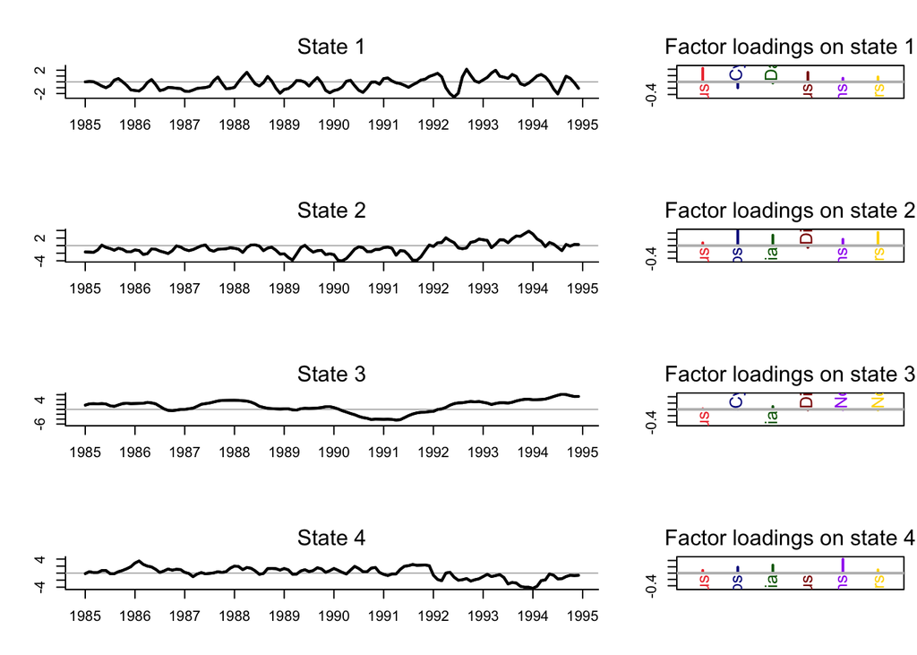

The above plot shows no clear pattern in species being driven by one trend or another. Perhaps cyclops and daphnia exhibit similar drivers and likewise with non-daphnid cladocerans and non-colonial rotifers. Also, despite including covariates to account for seasonal trends, there still appears to be some seasonality in states 1, 2, & 4.

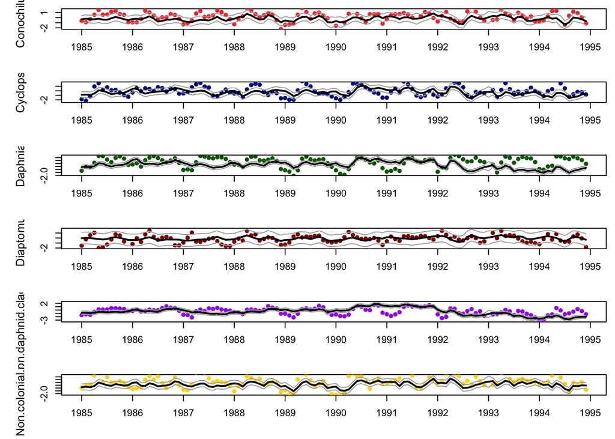

Finally, we compare model fit to the actual data for all six groupings of grazer zooplankton. Generally fit is good, with the model proving better at estimating abundances of certain species of zooplankton than others. Diaptomus, non-colonial rotifers, and conochilus estimates fit the data fairly well, while daphnia and to (maybe) a lesser extent non-daphnid cladocerans and cyclops estimates are less accurate predictions of the data observed.

# Discussion

Including phytoplankton abundance as a covariate in models describing the abundance of various grazing zooplaknton proved fruitful. A dynamic factor analysis revealed four underlying factors driving/predicting grazer abundance in Lake Washington. Phytoplaknton abundances were included in the model of best fit, along with pH levels and a seasonal component. While some species were modeled very effectively with this structure, others were not estimated as efficiently. A potential next step would be modeling each species of grazer separately in order to better capture the effects of phytoplankton abundance on each.

# Team contributions

Each team member contributed to a specific analysis. Tina modeled phytoplankton, Matheus modeled zooplankton, and Brian modeled zooplankton grazers with phytoplankton as covariates.